# Computational Statistics 13.2: Shrinkage

[figure not shown]

## Lasso and Ridge Regression

### Overview

This lesson introduces the lasso and ridge regression shrinkage methods.

### Objectives

After completing this module, students should be able to:

1. Explain how shrinkage methods work to reduce the number of variables in a model.
2. Distinguish between lasso, ridge regression, and elastic net.
3. Apply the glmnet package to estimate models with many independent variables.
4. Test and validate those models out-of-sample.

### Readings

Lander, 19.1

Recommended: James et al, [An Introduction to Statistical Learning](http://www-bcf.usc.edu/~gareth/ISL/ISLR%20Fourth%20Printing.pdf), Chapter 6.2.

## Data Reduction Methods - Factors

- In the previous module, we have already seen one potential method for reducing a large number of $x$ variables to few variables - principal component analysis -.
- In theory, to avoid overfitting, we could do a factor analysis on the set of independent variables, and replace them with a fewer factors.
- Each new variable $z$ would be the projection of that factor on the observations: that is, the score for each observation on that factor (eg, observation $i$ might be a 1.3 on the factor that ranges between sleepy and energetic in the `psych` data).
- The drawback is that, by replacing our existing and well-understood variables with the factors, might make the interpretation of the results harder and we might not capture as much of the variation in the data as the original variables did.

## Shrinkage

- A different approach might be to better select which subset of the variables *actually* influence $y$, and perhaps even weight them according to which ones have a greater or lesser contribution to predicting $y$.
- This should not be considered as a generalization of multiple regression, because we are using the $x$ variables with a different goal. We are not interested anymore in estimating the causal effect of $x$ on $y$, but simply using the variation in $x$ to predict $y$.

### Advantages (1/2)

- The *shrinkage* methods consists on taking the set of estimated coefficients, and, categorize them as:
  1. Equal to zero.
  2. Between zero and their estimated value.
  3. Equal to their estimated value.
- Then, those that are equal to zero are variables that are not contributing to explaining the variation of $y$, and are considered not part of the model. The in-between variables are kept in the model, but their parameters are reduce by a **shrinkage rate** and will have a lesser contribution when predicting $y$ – more details in next slides –. And the rest are kept as they are estimated.
- That is, instead of having a hard cut-off to determine significance (p-value $\leq$ 0.05) now we have a more gradual categorization, where the most significant $\beta$ coefficients stay as they would be from the regression, and others are *shrunk* more or less towards 0 depending on their significance levels.
- For all of you who were worrying about the arbitrariness of the p=0.05 cutoff, this approach might make you somewhat happier. But, again, this is not analogous to testing hypothesis.

### Advantages (2/2)

- Shrinkage actually allows us to use quite a few more independent variables without necessarily over-fitting $y$.
- Since the shrinkage rate – how severely $\beta$ coefficients with high p values (ie, the least significant ones) – is something we can set tweak, we can simply choose the optimal shrinkage rate given the dataset to maximize the out-of-sample accuracy of the model.
- If keeping too many coefficients *unshrunk* results in too much over-fitting and bad out-of-sample accuracy, we can can increase the shrinkage rate until only a couple of coefficients – the most statistically significant ones – are retained, and thus, keeping a smaller model that more accurately extrapolates to the out-sample data.

## Shrinkage methods

There are two similar methods for shrinkage, *lasso* and *ridge regression*, that have different historical origins but very similar structures.

### Lasso

**From multivariate regression analysis:**

- In the standard multiple regression model we estimate the $\beta$ coefficients that minimize the difference between $\hat{y}$ and $y$. Thus, we can obtain the $\beta$ coefficients by minimizing the $SSE$ or **squared sum of errors**
- Formally,

$$\underset{\beta}{\text{Min}} \sum_{i=1}^n (y_i - \hat{y}_i(\beta))^2 \equiv \underset{\beta_{0}, \beta_{1}, \beta_{2},...}{\text{Min}} \sum_{i=1}^n (y_i - \beta_0 - \beta_1 x_1 - \beta_2 x_2 ...)^2$$

- The solution to this minimization problem is what gives us our formula for calculating our $\beta$ coefficients from our dataset of $y$ and $x$ variables.

**Lasso Shrinkage Model:**

- The lasso shrinkage model follows a very similar process, with one crucial addition. Instead of just minimizing $SSE$, the lasso method adds a penalty for having to many significative parameters (parameters different than zero). Formally:

$$\sum_{i=1}^n (y_i - \beta_0 - \beta_1 x_1 - \beta_2 x_2 ...)^2 + \lambda \sum_{j=1}^p |\beta_j|$$

- This specification introduces a very important trade-off: on the one hand, if we keep all the $\beta$ coefficients at the values as estimated by the simple regression (top equation), we optimize the fit between $\hat{y}$ and $y$ – but, as we demonstrated last week, this can lead to overfitting –. But now, we’ll be penalized by having many variables in the model (a lot of parameters different than zero) as $\sum_{j=1}^p |\beta_j|$ will increase; on the other hand, we can reduce that second penalty to 0 by shrinking all the $\beta$ coefficients to 0, but at the cost of worsening the fit between $\hat{y}$ and $y$ (and thus increasing the first sum).
- The value $\lambda$ sets the trade-off between the two terms: when $\lambda$ is 0, we end up with the original multiple regression equation with entirely un-shrunk coefficients (which can easily suffer from overfitting); and when $\lambda$ is very large, the expression is almost entirely governed by the second sum, leading to most or all $\beta$ coefficients being shrunk to 0.

### Lasso continued

$$\sum_{i=1}^n (y_i - \beta_0 - \beta_1 x_1 - \beta_2 x_2 ...)^2 + \lambda \sum_{j=1}^p |\beta_j|$$

- The lasso method can be useful because sometimes it is worth getting a worse fit between $\hat{y}$ and $y$ in-sample, because it produces a better fit out-of-sample – and thus is better capturing the true population model, rather than simply overfitting.
- But to get this better out-of-sample validity, we often have to try a different set of $\lambda$ values to find the one that maximize the performance out-of-sample. Then, we have to use cross-validation to estimate $\lambda$.

### Ridge regression

- The second variant is ridge regression, which looks very similar to lasso, but with a different penalty for having significative parameters:

$$\sum_{i=1}^n (y_i - \beta_0 - \beta_1 x_1 - \beta_2 x_2 ...)^2 + \lambda \sum_{j=1}^p (\beta_j)^2$$

### Elastic net

One last option is to combine the two into a single shrinkage model, called *elastic net*:

$$\sum_{i=1}^n (y_i - \beta_0 - \beta_1 x_1 - \beta_2 x_2 ...)^2 + \lambda (\alpha \sum_{j=1}^p |\beta_j| + (1-\alpha) \sum_{j=1}^p (\beta_j)^2 )$$

As you can see, this once again has a single parameter $\lambda$ which sets the total amount of shrinkage, plus another parameter $\alpha$ that sets the proportion between the lasso and ridge amount ($\alpha$ ranges between 0 and 1, so the proportion can be anywhere between 100% lasso to 50/50 to 100% ridge). The elastic net is a simple linear combination of the lasso and ridge regression.

- You can develop your own shrinkage method by picking a different functional form for the penalty. Regardless of the functional form that you choose, we can always compare them using cross-validation.

## Example with `glmnet`

We use here an example from *An Introduction to Statistical Learning with Applications in R* (ISLR), which is a book on machine learning (and can be found online [here](http://www-bcf.usc.edu/~gareth/ISL/)) and happens to have been written by some of the creators of elastic net and the R package we will be using, `glmnet`.

We use a dataset from ISLR, on various baseball players, including their performance levels and salaries. Our goal is to predict their salaries using a set of variables. The dataset has 20 variables and 322 observations.

```r
#install.packages("glmnet")
#install.packages("ISLR") #datasets
library(ISLR)
data(Hitters)
dim(Hitters)
```

```
[1] 322  20
```

```r
head(Hitters)
```

```
                  AtBat Hits HmRun Runs RBI Walks Years CAtBat CHits
-Andy Allanson      293   66     1   30  29    14     1    293    66
-Alan Ashby         315   81     7   24  38    39    14   3449   835
-Alvin Davis        479  130    18   66  72    76     3   1624   457
-Andre Dawson       496  141    20   65  78    37    11   5628  1575
-Andres Galarraga   321   87    10   39  42    30     2    396   101
-Alfredo Griffin    594  169     4   74  51    35    11   4408  1133
                  CHmRun CRuns CRBI CWalks League Division PutOuts Assists
-Andy Allanson         1    30   29     14      A        E     446      33
-Alan Ashby           69   321  414    375      N        W     632      43
-Alvin Davis          63   224  266    263      A        W     880      82
-Andre Dawson        225   828  838    354      N        E     200      11
-Andres Galarraga     12    48   46     33      N        E     805      40
-Alfredo Griffin      19   501  336    194      A        W     282     421
                  Errors Salary NewLeague
-Andy Allanson        20     NA         A
-Alan Ashby           10  475.0         N
-Alvin Davis          14  480.0         A
-Andre Dawson          3  500.0         N
-Andres Galarraga      4   91.5         N
-Alfredo Griffin      25  750.0         A
```

### Data prepping

**Note:** We can use elastic net to model salaries as a function of the players’ various skills and achievements. `glmnet` works much like regression, but unlike `lm` it doesn’t understand factors, so it expects only a matrix of numeric variables – that is, you have manually create dummies for the factors –. For this example, we’ll just extract the independent variables (not including the dependent variable, Salary) from Hitters that are numeric and use them as the $x$ variables:

```r
Hitters <- na.omit(Hitters)
numericvars <- c(1:13,16:18)
x <- as.matrix(Hitters[,numericvars])
y <- Hitters$Salary
```

Alternatively, if you have factors, they can first be converted to dummies, using for instance `model.matrix` or `build.x` in the `useful` package (see Lander or the ISLR book for more on this).

- `glmnet` lets you set your alpha level for the proportion of lasso vs ridge regression; alpha=0 means pure ridge, and alpha=1 means pure lasso.
- Since the key question is setting the appropriate shrinkage level $\lambda$ (lambda), glmnet is designed to run repeatedly on a large number of different lambda settings, after which you can predict $\hat{y}$ for each shrinkage level, and see which predicted $\hat{y}$ best matches the real $y$ values out-of-sample.
- So next we set the levels of lambda (shrinkage) to tell glmnet to try, ranging from a very high lambda to a very low lambda:

```r
lambdalevels <- 10^seq(7,-2,length=100)
```

This gives us a 100-item sequence ranging from $10^7$ down to $10^{-2}$, which will cause glmnet to run the model 100 times, once with each of these lambda values. That is, first we’ll a very high $\lambda$ value (a big penalty for adding variables) and then a very low value (low penalty for adding variables, similar result to standard multivariate regression).

### Example, ridge

First let’s try it with alpha=0, ie, pure ridge. The formula is simple enough:

```r
#install.packages("glmnet") if you don't have the package installed
library(glmnet)
ridge.mod= glmnet(x, y, alpha=0, lambda = lambdalevels)
# Note that we don't have to specifcy a "formula"
# the x variables are added as a matrix and listed first
# the dependent variable y is a vector
# lambda is a vector of different lambda levels
```

glmnet stores the $\beta$ coefficients for every lambda level, so there are $(k \times \text{#-of-lambda-levels})$ coefficients stored. To see the 100th set of coefficients (for the smallest lambda), we can write:

```r
coef(ridge.mod)[,100]
```

```
 (Intercept)        AtBat         Hits        HmRun         Runs
126.74245930  -2.19339700   7.67471127   1.71439290  -1.88406702
         RBI        Walks        Years       CAtBat        CHits
  0.12400003   6.10591224  -2.74289815  -0.18258474   0.16444736
      CHmRun        CRuns         CRBI       CWalks      PutOuts
  0.03237573   1.50756927   0.68881161  -0.77369053   0.29461825
     Assists       Errors
  0.38724591  -2.95337311
```

### Ridge shrinkage visualized

We can also see how those various $\beta$ coefficients were shrunk down as we increase lambda from a small level of shrinkage (lambda=$10^{-2}$, close to standard multivariate regression) to a large level (lambda=$10^7$).

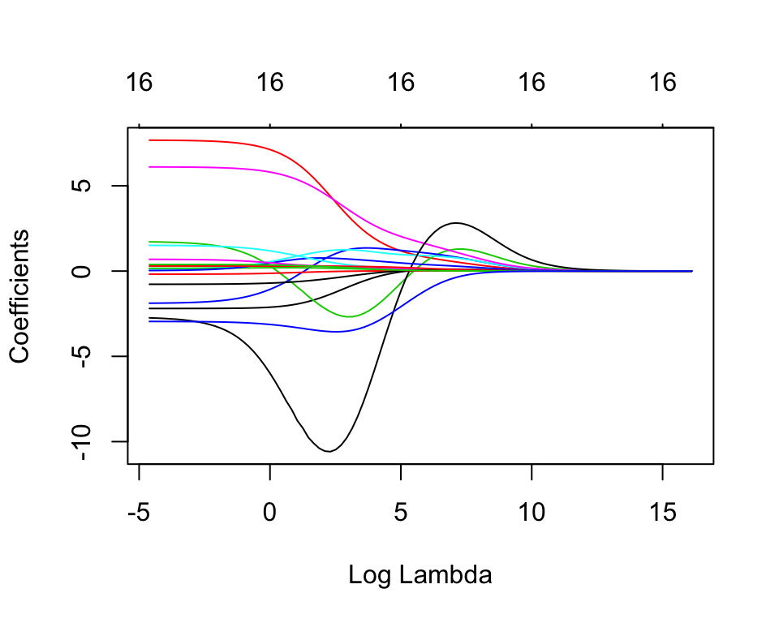

```r
plot(ridge.mod,xvar="lambda")
```

**Interpretation:**

- The coefficient values are plotted along the y axis, and the (natural log) lambda value along the x;
- a vertical slice for instance at log lambda=0 gives the values of the 16 coefficients at that level of shrinkage.
- One thing you can discern is that “shrinkage” is too simple a term: some coefficients actually can briefly grow in value for some levels of $\lambda$ if that minimizes the sum in the equation we defined above, although all parameters will eventually shrink to 0 when lambda is large enough.
- The big question is “what’s the optimal level of $\lambda$?”. We’ll explore the lasso model and then answer this directly.

### Example, lasso

We can do the same for a pure lasso model:

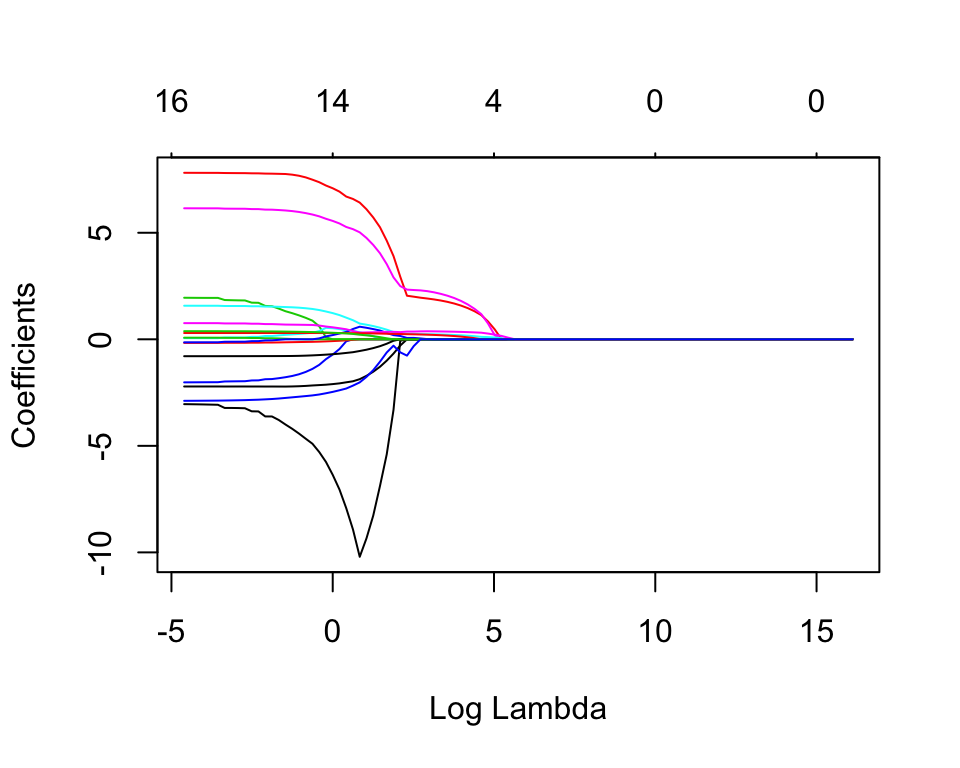

```r
lasso.mod=glmnet(x,y,alpha=1,lambda=lambdalevels)
plot(lasso.mod,xvar="lambda")
```

As can be seen, the results are not too dissimilar than the ridge method in this data.

## Choosing lambda

- Of course, what we most want is the value of $\lambda$ that produces the best out-of-sample fit – ie, that minimizes the out-of-sample mean squared error (MSE) or mean absolute error (MAE) between $\hat{y}$ and $y$.
- Fortunately for us, `glmnet` has built into it a cross-validation procedure based on MSE - phew! don’t have to code that! -, where it does k-fold cross validation for every level of lambda and calculated the MSE for each, and chooses the lambda with the lowest error. That is:
1. The data are divided into $k$ portions.
2. The model is fit on the in-sample (all but portion $k$), and for each level of lambda, $\hat{y}$ is predicted on the out-sample and the MSE for that lambda level is calculated.
3. Thus for each level of lambda there are $k$ MSE values, one for each of the $k$ out-of-sample tests.

### Choosing lambda visualized

We can then plot the average MSE for each lambda level (red dot), along with the 95% CI for that MSE (because we have $k$ of them for each lambda level):

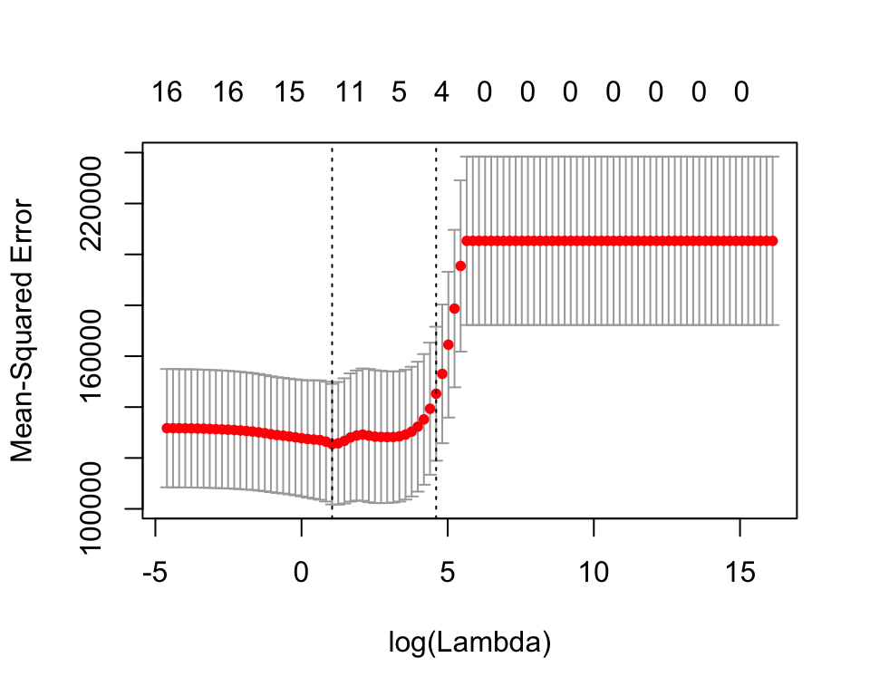

```r
set.seed(1)
cv.lasso.mod=cv.glmnet(x,y,alpha=1,lambda=lambdalevels)
plot(cv.lasso.mod)
```

- The dotted vertical line on the left shows the lambda that gets the best MSE, and the dotted line on the right is the MSE that is 1 standard error larger.
- The values along the top are the number of non-zero coefficients (after shrinkage).
- As we can see for this data, the best fit is with about 12 coefficients, but we do only one standard error worse (ie, statistically similar) with a model with only about 4 non-zero coefficients.
- Thus we can choose either the model with the best out-of-sample accuracy with 12 coefficients, or an only slightly-worse but much simpler model with 4 coefficients, or any combination between 12 and 4.
- If we want to know the coefficients for the best lambda, we can get the best lambda and plug it into `predict` with `s=` for the best lambda and `type="coefficients"` to get the coefficients:

```r
bestlambda <- cv.lasso.mod$lambda.min
predict(lasso.mod, type="coefficients",s=bestlambda)
```

```
17 x 1 sparse Matrix of class "dgCMatrix"
                     1
(Intercept) 76.4896752
AtBat       -1.7145436
Hits         6.1037612
HmRun        .
Runs         .
RBI          0.2484785
Walks        4.7562058
Years       -9.3407580
CAtBat       .
CHits        .
CHmRun       0.5407148
CRuns        0.6858672
CRBI         0.3235562
CWalks      -0.4882173
PutOuts      0.2800842
Assists      0.1852786
Errors      -1.7645945
```

Note how four variables have been shrunk to 0.

### Comparison with regression

**Is a shrinkage model better than a regular regression model for making predictions?**

**MSE for the standard multivariate regression:**

First we divide our data randomly into two equal halves, call each set of data: (1) the training set and (2) the test set:

```r
set.seed(1)
train <- sample (1:nrow(x),nrow(x)/2)
test <- (-train)
trainx <- x[train,]
testx <- x[test,]
trainy <- y[train]
testy <- y[test]
```

First let’s try regression. We fit the model on the training set, use the test data to predict $\hat{y}$, and then calculate the MSE of that vs the true test $y$:

```r
lmout <- lm(trainy~trainx)
yhat.r <- cbind(1,testx) %*% lmout$coefficients
# ^^ we predict via matrix multiplication rather than just using predict()
#    because x was made a matrix to make it work with glmnet
mse.reg <- sum((testy - yhat.r)^2)/nrow(testx)
mse.reg
```

```
[1] 128137
```

**MSE for lasso:**

```r
cv.lasso.mod=cv.glmnet(trainx,trainy,alpha=1,lambda=lambdalevels)
yhat.l <- predict(cv.lasso.mod$glmnet.fit, s=cv.lasso.mod$lambda.min, newx=testx)
# ^^ note how we give predict() our best lambda.min value to use for prediction
mse.las <- sum((testy - yhat.l)^2)/nrow(testx)
mse.las
```

```
[1] 106427.9
```

**Conclusion:**

So the lasso MSE seems better than the standard multivariate regression!

### Comparison with regression continued

**How much better is the lasso?**

- We can construct an number like $R^2$ to compare both models: we construct the total sum of squares (TSS) as the error between `testy` and the mean of `testy`.
- We then compare the sum of squared errors `sum((testy - yhat)^2)` for the two methods (regression and lasso).
- It’s not exactly an $R^2$ even for the regression because, of course, we are comparing $\hat{y}$ as predicted from one sample with $y$ in a different sample, rather than all in the same sample as we do with the proper $R^2$. We can call this measure pseudo-$R^2$ instead.

```r
tss <- sum((testy - mean(testy))^2)
sse.reg <- sum((testy - yhat.r)^2)
sse.las <- sum((testy - yhat.l)^2)
r2.r <- (tss - sse.reg) / tss
r2.l <- (tss - sse.las) / tss
r2.r
```

```
[1] 0.3349609
```

```r
r2.l
```

```
[1] 0.4476324
```

**Conclusion:**

- The out-of-sample pseudo-$R^2$ is considerably higher for the lasso than the regression method.
- Many other tests have established lasso and ridge regression (and elastic net more generally) as some of the most successful out-of-sample modeling methods.
- It is likely that the lasso model is doing a better job of fitting the real population, and not over-fitting due to having a high number of independent variables, the way the regular multiple regression is prone to do.
- Yet, keep in mind that this black-box approach is not ideal to test hypothesis and is not capturing the causal effect of $x$ on $y$. It is simply a method to make predictions. We are adding and excluding variables from the model without taking into account OVB or multicollinearity.
- Because this models are so good at making predictions, there is currently a lot of *hype* surrounding the discussion of machine learning. In particular, the fact that a model can out-perform other models in out-of-sample predictions, **does not mean that the estimated parameters are unbiased**.
- Finally, note how the estimation procedure requires to estimate the parameters hundres of times. This can be a serious processing power / RAM bottleneck, especially if $n$ is very large.